# Chapter 14, selected exercises

```r
library(rstanarm)
library(tidyverse)
```

## Exercise 14.3

Graphing Logistic Regressions

Graphing logistic regressions: The well-switching data described in Section 13.7 are in the folder Arsenic.

### Fit (a)

1. Fit a logistic regression for the probability of switching using log (distance to nearest safe well) as a predictor.

```r
wells <- read_csv('wells.csv')
wells <- wells |> mutate(log_dist = log(dist))
summary(wells)
```

```
##      switch          arsenic           dist            dist100
##  Min.   :0.0000   Min.   :0.510   Min.   :  0.387   Min.   :0.00387
##  1st Qu.:0.0000   1st Qu.:0.820   1st Qu.: 21.117   1st Qu.:0.21117
##  Median :1.0000   Median :1.300   Median : 36.761   Median :0.36762
##  Mean   :0.5752   Mean   :1.657   Mean   : 48.332   Mean   :0.48332
##  3rd Qu.:1.0000   3rd Qu.:2.200   3rd Qu.: 64.041   3rd Qu.:0.64041
##  Max.   :1.0000   Max.   :9.650   Max.   :339.531   Max.   :3.39531
##      assoc             educ            educ4          log_dist
##  Min.   :0.0000   Min.   : 0.000   Min.   :0.000   Min.   :-0.9493
##  1st Qu.:0.0000   1st Qu.: 0.000   1st Qu.:0.000   1st Qu.: 3.0501
##  Median :0.0000   Median : 5.000   Median :1.250   Median : 3.6045
##  Mean   :0.4228   Mean   : 4.828   Mean   :1.207   Mean   : 3.5642
##  3rd Qu.:1.0000   3rd Qu.: 8.000   3rd Qu.:2.000   3rd Qu.: 4.1595
##  Max.   :1.0000   Max.   :17.000   Max.   :4.250   Max.   : 5.8276
```

```r
fit_a <- stan_glm(switch ~ log(dist), data = wells,family = binomial(link = "logit"), refresh = 0)
print(fit_a, digits=3)
```

```
## stan_glm
##  family:       binomial [logit]
##  formula:      switch ~ log(dist)
##  observations: 3020
##  predictors:   2
## ------
##             Median MAD_SD
## (Intercept)  1.019  0.168
## log(dist)   -0.201  0.046
##
## ------
## * For help interpreting the printed output see ?print.stanreg
## * For info on the priors used see ?prior_summary.stanreg
```

*I wonder if I should center log distance?*

### (b) Make a graph similar to Figure 13.8b

Display Pr(switch) as a function of distance to nearest safe well, along with the data.

Borrowed from tidyros example

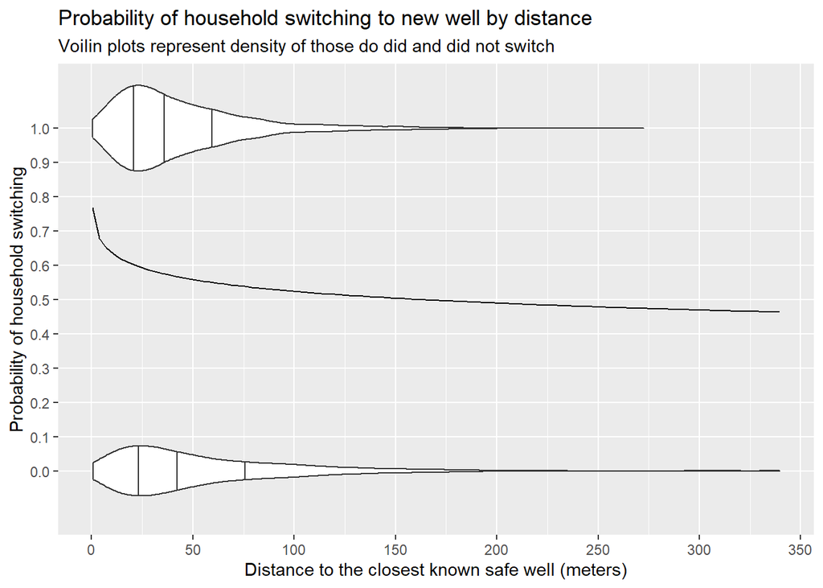

```r
v <-
  tibble(
    dist = seq(from=min(wells$dist), to = max(wells$dist), length.out=100),
    .pred = predict(fit_a, type = "response", newdata = tibble(dist))
  )

wells %>%
  ggplot(aes(dist)) +
  stat_ydensity(
    aes(y = switch, group = switch),
    width = 0.25,
    draw_quantiles = c(0.25, 0.5, 0.75),
    scale = "count"
  ) +
  geom_line(aes(y = .pred), data = v) +
  coord_cartesian(ylim = c(-0.125, 1.125)) +
  scale_y_continuous(breaks = seq(0, 1, 0.1), minor_breaks = NULL) +
  scale_x_continuous(breaks = scales::breaks_width(50)) +
  labs(
    title = "Probability of household switching to new well by distance",
    subtitle =
      "Voilin plots represent density of those do did and did not switch",
    x = "Distance to the closest known safe well (meters)",
    y = "Probability of household switching"
  )
```

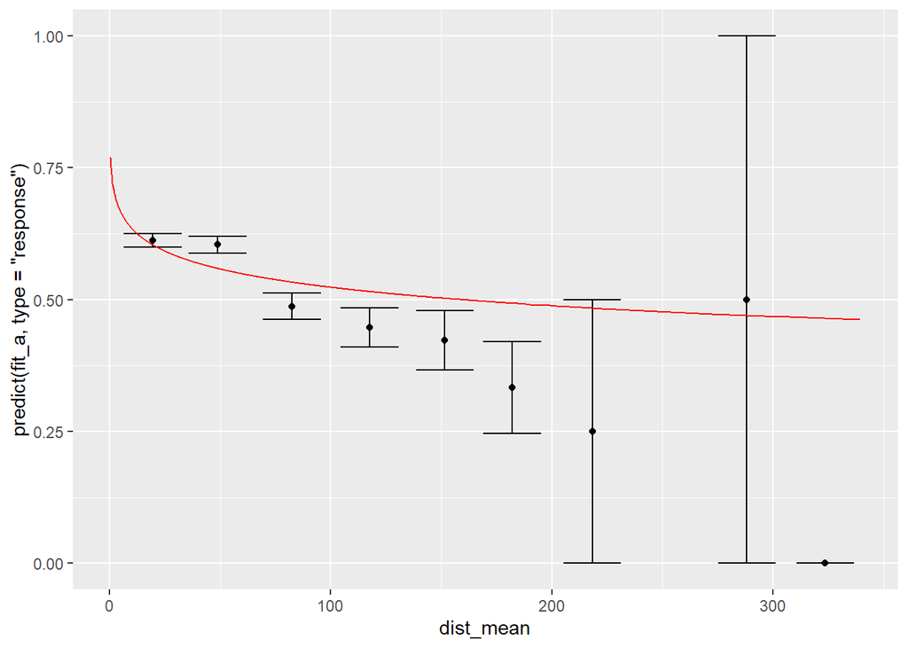

```r
binned <- wells |>  mutate(bin = cut_interval(dist,n = 10)) |>
        group_by(bin) |>
             summarize(
             dist_mean = mean(dist),
             p_switch = mean(switch),
             p_se = sd(switch) / sqrt(n())
             )



binned |>
  ggplot() +
  geom_errorbar(aes(x= dist_mean, ymin = p_switch - p_se,ymax = p_switch + p_se)) +
  geom_line(aes(x = dist, y = predict(fit_a, type = "response")),data=wells, color='red') +
  geom_point(aes(x=dist_mean, y= p_switch))
```

### (c) Make a residual plot and binned residual plot as in Figure 14.8.

I am only going to show binned residual plot

This code borrowed from the tidy-ros examples:

```r
plot_binned_residuals <- function(data) {
  data %>%
    ggplot(aes(x_mean)) +
    geom_hline(yintercept = 0, color = "white", size = 2) +
    geom_line(aes(y = 2 * y_se), color = "grey60") +
    geom_line(aes(y = -2 * y_se), color = "grey60") +
    geom_point(aes(y = y_mean)) +
    labs(y = "Average residual")
}

binned_means <- function(x, y, n_bins = 40) {
  tibble(x, y) %>%
    mutate(bin = cut_number(x, n = n_bins)) %>%
    group_by(bin) %>%
    summarize(
      x_mean = mean(x),
      y_mean = mean(y),
      y_se = sd(y) / sqrt(n())
    )
}
```

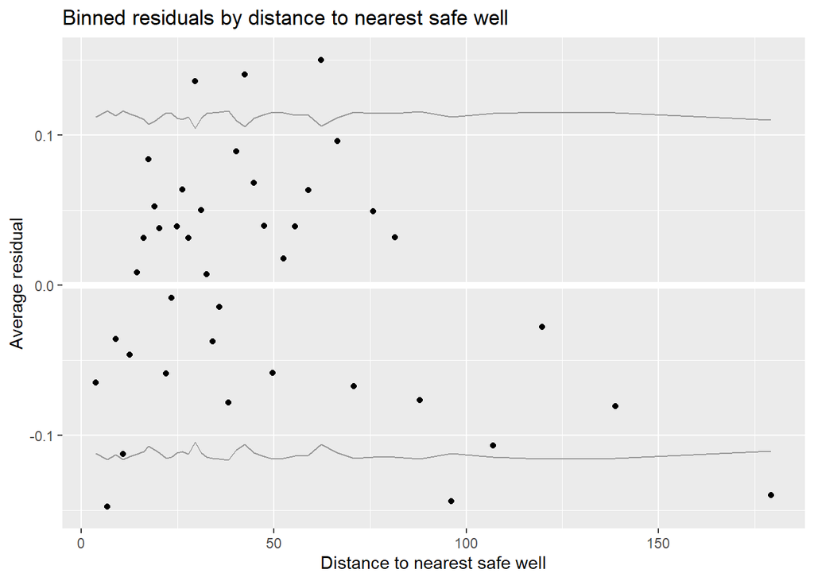

```r
v <-
  binned_means(
    x = wells$dist,
    y = residuals(fit_a)
  )

v %>%
  plot_binned_residuals() +
  labs(
    title = "Binned residuals by distance to nearest safe well",
    x = "Distance to nearest safe well"
  )
```

### (d) Compute the error rate of the fitted model and compare to the error rate of the null model.

Error rate of the null model:

```r
wells |> summarize(null_switch = mean(switch))
```

```
## # A tibble: 1 × 1
##   null_switch
##         <dbl>
## 1       0.575
```

So the error rate is 1- that, about 42.5%

For the fitted model:

```r
pred <- predict(fit_a, type='response')
mean((pred > 0.5 & wells$switch==1) | (pred <= 0.5 &  wells$switch==0))
```

```
## [1] 0.5811258
```

ok, so better then null!

### (e) Large Binns

Create indicator variables corresponding to dist < 100; dist between 100 and 200; and dist > 200. Fit a logistic regression for Pr(switch) using these indicators. With this new model, repeat the computations and graphs for part (a) of this exercise.

```r
wells <- wells |>
  mutate(
    dist_cut = cut(dist,c(0,100,200,1000))

  )

fit_e <- stan_glm(switch ~ dist_cut - 1 ,
                  data = wells, family= binomial(link="logit"), refresh = 0)
```

```r
print(fit_e, digits =3)
```

```
## stan_glm
##  family:       binomial [logit]
##  formula:      switch ~ dist_cut - 1
##  observations: 3020
##  predictors:   3
## ------
##                     Median MAD_SD
## dist_cut(0,100]      0.373  0.040
## dist_cut(100,200]   -0.283  0.119
## dist_cut(200,1e+03] -1.385  0.834
##
## ------
## * For help interpreting the printed output see ?print.stanreg
## * For info on the priors used see ?prior_summary.stanreg
```

Plot it

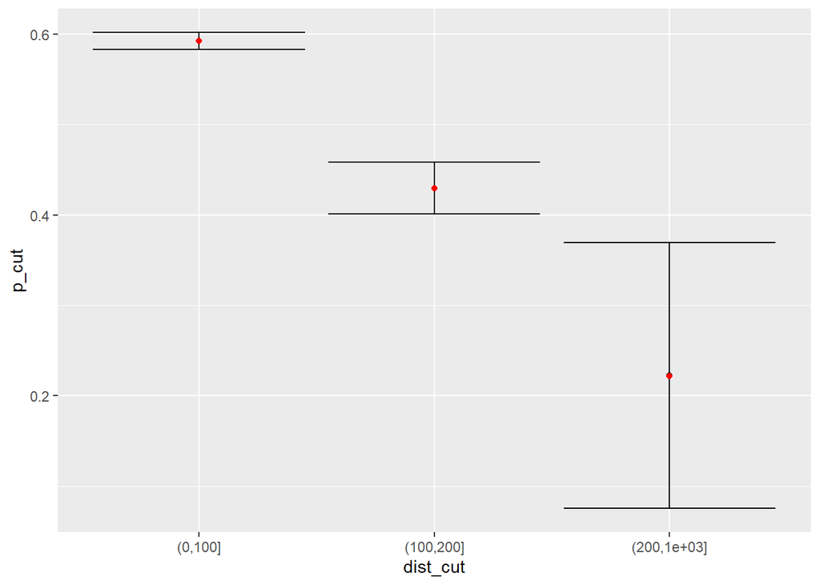

```r
binned <- wells |>
          group_by(dist_cut) |>
          summarise(p_cut = mean(switch), sd_cut = sd(switch) / sqrt(n()) )
binned <- binned |>
  mutate(.pred = predict(fit_e, type = "response", newdata = binned))

binned |>
  ggplot() +
  geom_point(aes(x=dist_cut, y= p_cut)) +
  geom_errorbar(aes(x= dist_cut, ymin = p_cut - sd_cut,ymax = p_cut + sd_cut)) +
  geom_point(aes(x = dist_cut, y = .pred), color='red')
```

```r
binned
```

```
## # A tibble: 3 × 4
##   dist_cut    p_cut  sd_cut .pred
##   <fct>       <dbl>   <dbl> <dbl>
## 1 (0,100]     0.592 0.00944 0.592
## 2 (100,200]   0.430 0.0287  0.429
## 3 (200,1e+03] 0.222 0.147   0.222
```

At first I was surprised, but then I recalled that fitting to a constant is the same as estimating the proportion, which is all we are doing for each bin!

```r
as_tibble(fit_e) |> pivot_longer( everything(), names_to = 'bin', values_to = 'coef' ) |>
  group_by(bin) |> summarize(mean = mean(invlogit(coef)), sd = sd(invlogit(coef)))
```

```
## # A tibble: 3 × 3
##   bin                  mean      sd
##   <chr>               <dbl>   <dbl>
## 1 dist_cut(0,100]     0.592 0.00942
## 2 dist_cut(100,200]   0.429 0.0283
## 3 dist_cut(200,1e+03] 0.222 0.130
```

### Alternate plot to better illustrate the fit IMHO

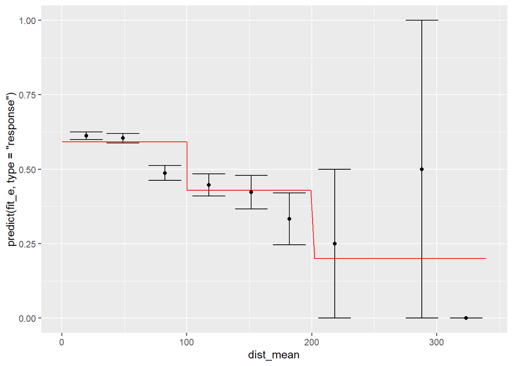

```r
binned <- wells |>  mutate(bin = cut_interval(dist, n = 10)) |>
        group_by(bin) |>
             summarize(
             dist_mean = mean(dist),
             p_switch = mean(switch),
             p_se = sd(switch) / sqrt(n())
             )



binned |>
  ggplot() +
  geom_errorbar(aes(x= dist_mean, ymin = p_switch - p_se,ymax = p_switch + p_se)) +
  geom_line(aes(x = dist, y = predict(fit_e, type = "response")),data=wells, color='red') +
  geom_point(aes(x=dist_mean, y= p_switch))
```

### How bad is the prediction accuracy?

```r
pred <- predict(fit_e, type='response')
mean((pred > 0.5 & wells$switch==1) | (pred <= 0.5 &  wells$switch==0))
```

```
## [1] 0.5907285
```

Slightly better?